# Auxiliary information

2025-05-22

### Occupancy model with spatially uncorrelated/unstructured random effects

Below we describe the multi-season site occupancy model of (Outhwaite et al. 2018) which we used in the sensitivity analyses. This model represents an improvement from the occupancy model used in (Isaac et al. 2014) in the sense that it uses a random walk (normally distributed) prior for the temporal random effect parameter $b_t$, thus enabling the sharing of occupancy information between consecutive years to estimate occupancy trends. The model can be described in the following manner (respecting the hierarchical structure we used in our main text, and using parameter notation as (Outhwaite et al. 2018)).

The first part of the model is an occupancy state process, where the latent occupancy state $z_{it}$ of a single species at $i=1, ..., I$ sites and $t=1, ..., T$ primary occasions is modeled. The state $z_{it}$ is drawn from a Bernoulli distribution depending on the probability of occupancy of the site $\psi_{it}$. The $\psi_{it}$ is modeled in function of covariates varying over sites and / or primary occasions $X_{it}$, and $\boldsymbol{\beta}$ is a vector of regression coefficients including the intercept and slope (eq. 1):

$$\tag{1}
\begin{equation}
\begin{split}
z_{it}|\psi_{it} \sim \mathcal{B}(\psi_{it}), \\
\text{logit}(\psi_{it}) = X_{it}^T\boldsymbol{\beta} + u_{i} + b_{t}
\end{split}
\end{equation}$$

The original model formulation has no covariates. Some formulations include one intercept coming from a Beta ($\mathcal{B}e$) distribution. We also changed the formulation of the spatially uncorrelated random effects $u_{i}$ , which here were defined through two Normal distributions with $\mu=0$ and variance $\sigma^2_u$ for each site $i$ to ensure the identifiability of the model intercept. Thus we used eq. 2:

$$\tag{2}
\begin{equation}
\begin{split}
u_i \sim
\begin{cases}
\mathcal{N}(0,10^4) & \text{for } i=1 \\
\mathcal{N}(u_{i},\tau_u) & \text{for } i>1
\end{cases}
\end{split}
\end{equation}$$

where $\tau_u$ is precision parameter calculated as $1/\sigma^2_u$. This parameter controls the variance of occupancy probability across sites. The prior for $u_1$ is Normal with $\mu_b=0$ and variance $10^4$, and priors for successive sites are determined via the second term in eq. 2. The prior for $\sigma^2_u$ was $\sigma_u\sim U(0,5)$.

The temporal random effect $b_{t}$ follows a random walk model defined in eq. 3:

$$\tag{3}
\begin{equation}
\begin{split}
b_t \sim
\begin{cases}
\mathcal{N}(\mu_b,10^3) & \text{for } t=1 \\
\mathcal{N}(b_{t-1},\tau_b) & \text{for } t>1
\end{cases}
\end{split}
\end{equation}$$

where $\tau_b$ is precision parameter calculated as $1/\sigma^2_b$, this parameter controls the variance of species occupancy probability in time $t$ relative to the previous time $t-1$. The prior for $b_1$ came from a Normal distribution with $\mu_b=0$ and variance $10^3$, and priors for successive time points are determined via the second term in eq. 2. The prior for $\sigma^2_b$ was $\sigma_b\sim U(0,5)$.

The detection model of Outhwaite et al. (2018) includes the year effect in the model intercept. Since we want something similar to Doser and Stoudt (2024) model, the detection model we implemented eq. 4:

$$\tag{4}
\begin{equation}
\begin{split}
y_{itj} | z_{it} \sim \mathcal{B}(z_{it} \times p_{itj}) ,\\
\text{logit}(p_{itj}) = v_{itj}^T\boldsymbol{\alpha}
\end{split}
\end{equation}$$

where $\boldsymbol{\alpha}$ is a vector of regression coefficients, including the intercept and slopes that represent the effect of the covariates $v_{itj}$ on $p_{itj}$ (eq. 4). The species encounter history $y_{itj}$ is then conditionally related to the latent occupancy $z_{it}$, meaning that for a truly occupied site and primary occasion $z_{it}=1$, the species will be detected in one individual secondary occasion with probability $p_{j}$ (eq. 4). If unoccupied $z_{it}=0$ then the species can not be detected.

Prior choice has a large influence on the performance of Outhwaite’s model (see supplementary material in (Outhwaite et al. 2018)). The original model formulation had $\beta_0 \sim \mathcal{B}e(\alpha,\beta)$, with $\alpha$ and $\beta$ controlling the shape of the distribution (not to be confused with model coefficients presented above). In our analyzes, we followed the authors and set both parameters to $\alpha, \beta = 2$. The same prior was set to the detection intercept $\alpha_0$. The inverse logit function was then applied to this quantity. Priors for regression slopes (from both occupancy and detection models) were taken from a Normal distribution with average and precision as $\mathcal{N} (0,0.001)$.

This model was fitted to 42 simulated data sets under the design of study 2 - scenario 1 (Poisson sampling design, effect of latitude $L_i$ on occupancy, effect of observation-level covariate $v_{itj}$ on detection). The model was written in BUGS language and analyzed in JAGS through the R package jagsUI (Kellner 2024). Parameter estimates using the real data set was done with three parallel MCMC chains of 10,000 iterations each, burn-in of 5,000 iterations, and thinning each 10 iterations (yielding 1,500 posterior distribution draws in total). It took 18 days to run the model for 42 data sets x 16 autocorrelation scenarios per data set using a Dell Inc. Precision Tower 3620 with processor Intel(R)Xeon(R)E3-1240 v5x8 with 32GB RAM and 8 cores.

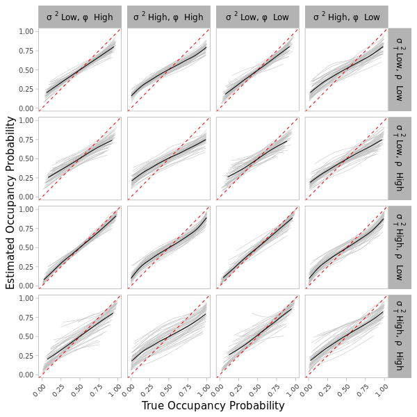

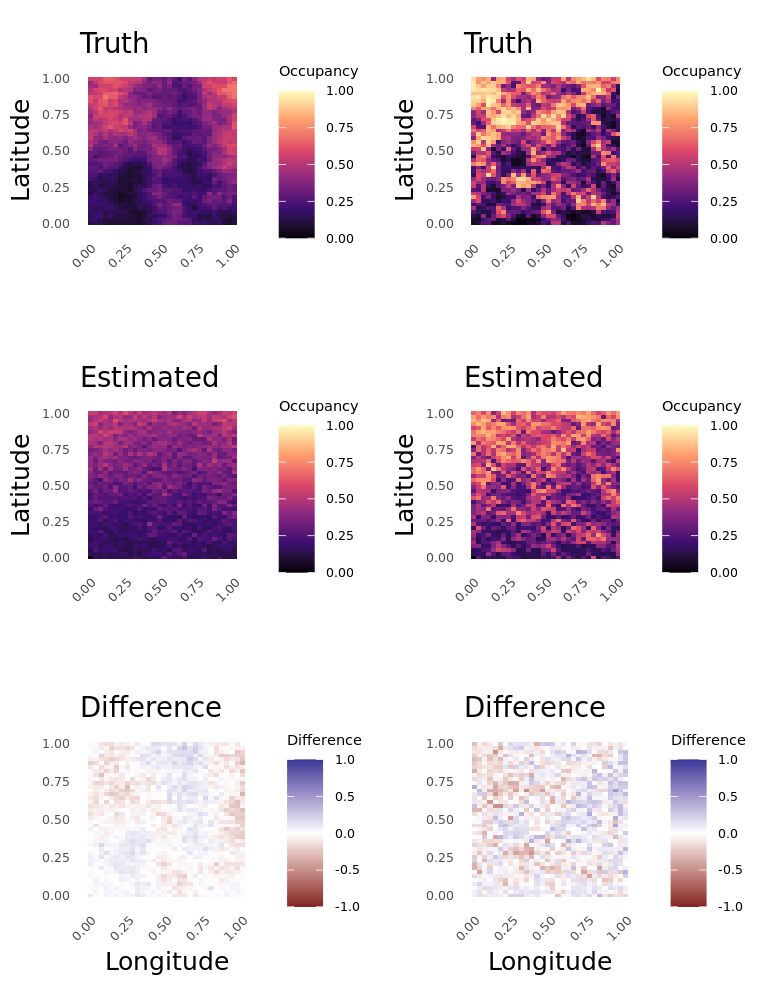

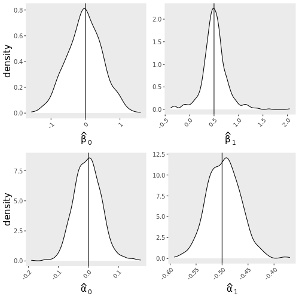

### References

Doser, Jeffrey W., and Sara Stoudt. 2024. “‘Fractional Replication’ in Single‐visit Multi‐season Occupancy Models: Impacts of Spatiotemporal Autocorrelation on Identifiability.” *Methods in Ecology and Evolution* 15 (2): 358–72. https://doi.org/10.1111/2041-210X.14275.

Isaac, Nick J. B., Arco J. Van Strien, Tom A. August, Marnix P. De Zeeuw, and David B. Roy. 2014. “Statistics for Citizen Science: Extracting Signals of Change from Noisy Ecological Data.” Edited by Barbara Anderson. *Methods in Ecology and Evolution* 5 (10): 1052–60. https://doi.org/10.1111/2041-210X.12254.

Kellner, Ken. 2024. *jagsUI: A Wrapper Around ’Rjags’ to Streamline ’JAGS’ Analyses*. https://CRAN.R-project.org/package=jagsUI.

Outhwaite, Charlotte L, Richard E Chandler, Gary D Powney, Ben Collen, Richard D Gregory, and Nick JB Isaac. 2018. “Prior Specification in Bayesian Occupancy Modelling Improves Analysis of Species Occurrence Data.” *Ecological Indicators* 93: 333–43. https://www.sciencedirect.com/science/article/pii/S1470160X18303443?via%3Dihub.